[figure not shown]

# pythoninchemistry

## The interaction between simulation and scattering

# Classical Methods

### Overview

**Questions**

- What is a classical potential?
- How would I model a van der Waals interaction?

**Objectives**

- Introduce classical potential models
- Show examples of functions used to model non-bonded interactions

**Classical methods** is the phrase used to describe all simulation methods that make use of a potential model (you may also hear the term force-field) to rationalise chemical systems. These can be molecular dynamics, Monte Carlo, Langevin dynamics, etc. However, we will focus on the application in molecular dynamics.

Classical methods are distinct from *quantum mechanical* methods, such as density functional theory (DFT). In classical methods, the quantum mechanical **weirdness** is not present, which has a significant impact on the efficiency of the calculation. The requirement to utilise quantum mechanics is removed by integrating over all of the electronic orbitals and motions; by describing the atom with a **fixed electron distribution**. This **simplification** has some drawbacks, classical methods are only suitable for the study of the molecular ground states, limiting the ability to study reactions. Furthmore, more revelant to this course, it is **necessary** to use a well parameterised potential model.

## Potential models

The aim of a lot of chemistry/physics is to understand the **energy** of the given system, therefore it is necessary to **parameterise** out models. In practice, the model used to describe the electron distribution is usually **isotropic**, e.g. a sphere for the atom) The electron bonds between atoms are then described as springs (*Figure 1*). For a molecular system, the energy is defined in terms of bonded and non-bonded interactions,

$$ E_{\text{tot}} = E_{\text{bond}} + E_{\text{angle}} + E_{\text{dihedral}} + E_{\text{non-bond}} $$

where, $E_{\text{bond}}$, $E_{\text{angle}}$, and $E_{\text{dihedral}}$ are the energies associated with all of the bonded interactions, and $E_{\text{non-bond}}$ is the energy associated with all the of the non-bonded interactions. This tutorial will focus **only** on the non-bonded interactions. However, as with non-bonded interactions, bonded interactions must be parameterised according to the chemistry of the bond.

[figure not shown]

*Figure 1. A pictorial example of the models used in a classical method.*

### Coulomb's law

Potential model parameterisation involves the use of **mathematical functions** to describe the physical relationship between atoms. For example, one of the most common non-bonded interactions is the electrostatic interaction between two charged particles, to model this interaction we use **Coulomb's law**, which was first defined in 1788 [1, 2],

$$ E_{\text{Coulomb}}(r_{ij}) = \frac{1}{4\pi\epsilon_0}\frac{q_iq_je^2}{r_{ij}}, $$

where, $q_i$ and $q_j$ are the electronic charge on the particles, $e$ is the charge of the electron, $\epsilon$ is the dielectric permitivity of vacuum, and $r_{ij}$ is the distance between the two particles.

The Python code below defines a function that models the electrostatic interaction using Coulomb's law and plots it.

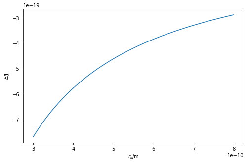

```python
%matplotlib inline
import numpy as np
import matplotlib.pyplot as plt
from scipy.constants import e, epsilon_0

def coulomb_energy(qi, qj, rij):
    """
    Calculation of Coulomb's law.

    Parameters
    ----------
    qi: float
        Electronic charge on particle i
    qj: float
        Electronic charge on particle j
    rij: float
        Distance between particles i and j

    Returns
    -------
    float
        Energy of the Coulombic interaction
    """
    return (qi * qj * e ** 2) / (4 * np.pi * epsilon_0 * rij)

r = np.linspace(3e-10, 8e-10, 100)
fig = plt.figure(figsize=(8, 5))
ax = fig.add_subplot(111)
ax.plot(r, coulomb_energy(1, -1, r))
ax.set_xlabel(r'$r_{ij}$/m')
ax.set_ylabel(r'$E$/J')
plt.show()
```

The above code and plot can be thought of as the interaction between a sodium ion (Na<sup>+</sup>) and a chloride ion (Cl<sup>-</sup>). These ions have opposite charges and therefore will be very strongly attracted to each other. From this, it is clear that this mathematical function has clear roots in the **chemistry of the system**. The charges for atoms with a formal charge (e.g. with an integer positive or negative) are straight-forward to determine. However, consider the partial charge on the oxygen atom within a carbonyl functional group, what is the charge of this? This is something that would have to be determined during the parameterisation.

### The van der Waals interaction

The mathematical function for the uncharged component of the non-bonded interaction is less well defined. This is the **van der Waals** interaction, which encompasses both the attractive London dispersion effects and the repulsive Pauli exclusion principle. There are a variety of ways that the van der Waals interaction can be modelled.

One commonly applied method is the **Lennard-Jones** potential model, which considers the attractve London dispersion effects as follows,

$$ E_{\text{attractive}}(r_{ij}) = \dfrac{-B}{r_{ij}^6},$$

where $B$ is some constant for the interaction, and $r_{ij}$ is the distance between the two atoms. The Pauli exclusion principle is repulsive and only present over very short distances, and is therefore modelled with the relation,

$$ E_{\text{repulsive}}(r_{ij}) = \dfrac{A}{r_{ij}^{12}},$$

where $A$ is some interaction specific constant. The Python code below defines each of the components of the Lennard-Jones potential, and the total energy of the interaction. These are then all plotted on a single graph. The values of $A$ and $B$ are those associated with an argon-argon interaction, as defined by Rahman [3].

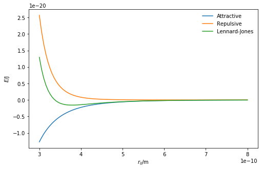

```python
def attractive_energy(rij, b):
    """
    Attractive component of the Lennard-Jones interaction
    energy.

    Parameters
    ----------
    rij: float
        Distance between particles i and j
    b: float
        B parameter for interaction between i and j

    Returns
    -------
    float
        Energy of attractive component of Lennard-Jones
        interaction
    """
    return -b / np.power(rij, 6)

def repulsive_energy(rij, a):
    """
    Repulsive component of the Lennard-Jones interaction
    energy.

    Parameters
    ----------
    rij: float
        Distance between particles i and j
    a: float
        A parameter for interaction between i and j

    Returns
    -------
    float
        Energy of repulsive component of Lennard-Jones
        interaction
    """
    return a / np.power(rij, 12)

def lj_energy(rij, a, b):
    """
    Implementation of the Lennard-Jones potential
    to calculate the energy of the interaction.

    Parameters
    ----------
    rij: float
        Distance between particles i and j
    a: float
        A parameter for interaction between i and j
    b: float
        B parameter for interaction between i and j

    Returns
    -------
    float
        Energy of the interaction between i and j.
    """
    return repulsive_energy(rij, a) + attractive_energy(rij, b)

r = np.linspace(3e-10, 8e-10, 100)
fig = plt.figure(figsize=(8, 5))
ax = fig.add_subplot(111)
ax.plot(r, attractive_energy(r, 9.273e-78), label='Attractive')
ax.plot(r, repulsive_energy(r, 1.363e-134), label='Repulsive')
ax.plot(r, lj_energy(r, 1.363e-134, 9.273e-78), label='Lennard-Jones')
ax.set_xlabel(r'$r_{ij}$/m')
ax.set_ylabel(r'$E$/J')
ax.legend(frameon=False)
plt.show()
```

The Lennard-Jones potential is not the only way to model the van der Waals interaction. Another commonly applied potential model is the **Buckingham** potential. Similar to the Lennard-Jones potential, the Buckingham models the attractive term with a power-6. However, instead of the power-12 repulsion, this is modelled with an exponential function. The total Buckingham potential has the following form,

$$ E_{\text{Buckingham}}(r_{ij}) = A\exp{-Br_{ij}} - \dfrac{C}{r_{ij}^6}, $$

where $A$, $B$, and $C$ are interaction specific parameters that must be determined. N.B. these are not the same $A$ and $B$ as in the Lennard-Jones potential.

The Python code below allows the comparison between these two van der Waals potentials, using defined parameters for the argon-argon interaction [3, 4].

### Potential models

These are just two of many potentials for modelling of the van der Waals interation. Furthermore, the parameters used in the model are just one example of the many possible parameterisations of the argon-argon interaction.

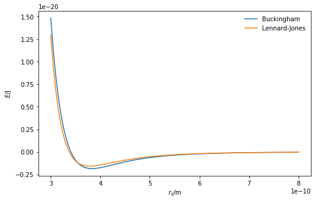

```python
def buckingham_energy(rij, a, b, c):
    """
    Implementation of the Buckingham potential
    to calculate the energy of the interaction.

    Parameters
    ----------
    rij: float
        Distance between particles i and j
    a: float
        A parameter for interaction between i and j
    b: float
        B parameter for interaction between i and j
    c: float
        C parameter for interaction between i and j

    Returns
    -------
    float
        Energy of the interaction between i and j.
    """
    return a * np.exp(-b * rij) - c / np.power(rij, 6)

r = np.linspace(3e-10, 8e-10, 100)
fig = plt.figure(figsize=(8, 5))
ax = fig.add_subplot(111)
ax.plot(r, buckingham_energy(r, 1.69e-15, 3.66e10, 1.02e-77), label='Buckingham')
ax.plot(r, lj_energy(r, 1.363e-134, 9.273e-78), label='Lennard-Jones')
ax.set_xlabel(r'$r_{ij}$/m')
ax.set_ylabel(r'$E$/J')
ax.legend(frameon=False)
plt.show()
```

There is a small but clear difference between the interaction energies for each potential, this indicates the variation that is present in model parameterisation.

### Key Points

- Classical methods simplify the atomistic modelling by treating the atoms using mathematical functions
- There are a wide range of different mathematical functions available

### References

1. Coulomb, C. A. (1788). Histoire de l’Académie Royale des Sciences. Imprimerie Royale. 569–577
2. Coulomb, C. A. (1788). Histoire de l’Académie Royale des Sciences. Imprimerie Royale. 578–611
3. Rahman, A. (1964). Phys. Rev., **136**, A405. https://doi.org/10.1103/PhysRev.136.A405
4. Buckingham, R. A. (1938). Proc. Royal Soc. Lond. A, **168**, 264-283. https://doi.org/10.1098/rspa.1938.0173